# Wining and Dining: Data Science Edition

Your friend from school has just returned from their gap year as a [WWOOF-er](https://wwoof.org.uk/) in a small estate outside of Lyon. They claim that there’s nothing quite like a French wine. They’re better, more expensive, and they won’t let you forget it!

But, you have your doubts:

> *Are French wines really the best, or are they just more expensive for the same quality?*

So you, now a freshly minted data scientist, decide to moonlight as a data sommelier. Your overarching mission: shed some light on this question.

# 0 The Data

You find a nice dataset of [all the wine ratings](https://www.kaggle.com/zynicide/wine-reviews) from *WineMag*, a lifestyle magazine about wine & winemaking, and get to work.

```r
library(tidyverse)
wines = read_csv('http://ljwolf.org/teaching/gds/wines.csv')
wines %>% head(1) %>% knitr::kable()
```

| X1 | country | description | designation | points | price | province | region_1 | region_2 | variety | winery |
| --- | --- | --- | --- | --- | --- | --- | --- | --- | --- | --- |
| 0 | US | This tremendous 100% varietal wine hails from Oakville and was aged over three years in oak. Juicy red-cherry fruit and a compelling hint of caramel greet the palate, framed by elegant, fine tannins a… | Martha’s Vineyard | 96 | 235 | California | Napa Valley | Napa | Cabernet Sauvignon | Heitz |

As you can see, the data contains information on the `country` the wine is from, as well as the `province`, the macro-level `region` (which is below the `province`) and the micro-level `region_2` (which is below the `region_1`). The `designation` represents the part of the vinyard where the vintner claims the wine comes from. The `price` is the price (in dollars) of the wine. The `points` are the rating of the wine, given by *WineMag*’s judges. Finally, the `variety` reflects the grape (or grapes) used to make the wine, and the `winery` reflects the name of the winery that grew the wine.

# 1 Exploration & Visualization

This section, please use tidy transformation, like `group_by` and `summarize`, to obtain the answers to these questions.

## 1.1

What is your best guess about the price and rating of wines from each country?

## 1.2

What is the highest rating attained by a wine in each country?

## 1.3

Using `ggplot`, show me the distribution of the ratings of wines in each country.

## 1.4

[Orson Welles disagrees with your friend, and thinks that the US is almost as good as France at making champagne…but he was paid a lot in free US wine to say so!](https://www.youtube.com/watch?v=Nvxwf1jxdaM)

Does your dataset agree? Are American champagnes rated as highly (on average) as French champagnes?

Remember: the `variety` column contains the kind of grape that made the wine. And, most Champagne wines are actually `Champagne Blend`, when you’re as pedantic as the typical *WineMag* reader 😁

## 1.5 **challenge**

What are the two most common `variety` of wine in each country?

# 2 Who has the best wine?

Fit a standard linear model predicting `points` using `country`. According to this model, which country has the most highly rated wines? Is this significant?

# 3 What is the relationship between price and quality?

Look at the plot showing the relationship between price and quality for each country in the data.

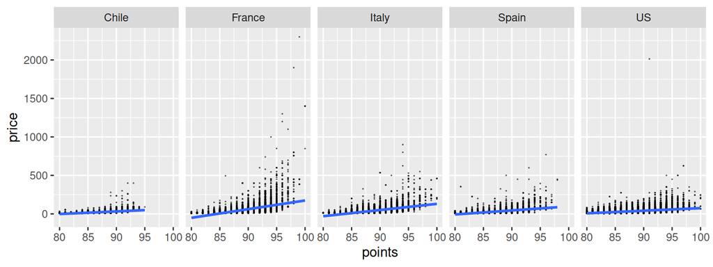

## 3.1

From the plot above, does the relationship between price and rating appear to be constant over countries? Does the relationship appear to be linear? What visualization technique is used to aid comparison of the countries’ relationships between price and points?

## 3.2

Fit a multilevel model predicting the `price` using `points` that allows the slope and intercept to vary by country.

Remember to center your X variables when running multilevel models! This improves the numerical stability of the estimating algorithms, and makes it easier to interpret $\alpha$ as “the mean of $y$ when $x$ is at its mean.”

### 3.2.1

In the model from 3.2, which country has the lowest baseline price for an average-rated wine? Is it statistically significantly different from the other countries?

### 3.2.2

In the model from 3.2, which country pays the highest “premium” for higher-rated wine? Is this statistically significantly different from the other countries?

Another way of phrasing this is: which country’s prices rise the fastest for each point of rating? Who’s over-charging?

## 3.3

Given your interpretations from Section 3.2, is French wine higher quality or just overpriced?

It’s also ok if the true answer is somewhere in between!

## 3.4 **Challenge**

Your friend says they bought a 100-point wine for about $70, but are not sure where it is from.

You use your model model to predict the price of a 100-point wine in every country, and find that it might have come from one of two countries. Given what you have done in Section 1 and here, which country do you think is more likely and why?

Remember that you may have centered your variables! 100 points is *not* the same as 100 points above the mean rating!

# 4 Can we predict where a wine comes from?

Using logistic regression…

## 4.1

Fit a model predicting whether a wine is from France using the wine’s price and rating. In this model,

### 4.1.1

Do more expensive wines tend to be from France?

### 4.1.2

Do more highly-rated wines tend to be from France?

### 4.1.3

Using a cutoff of .2, show me the confusion matrix. How many French wines does our model classify correctly?

## 4.2

Now, fit a model predicting whether a wine is from the United States using the wine’s price and rating. In this model,

### 4.2.1

Do more expensive wines tend to be from the US?

### 4.2.2

Do more highly-rated wines tend to be from the US?

### 4.2.3

Using a cutoff of .5, show me the confusion matrix. How many American wines does our model classify correctly?

## 4.3 **Challenge**

At what **exact** threshold is the accuracy maximized in each model? And, which model can attain the highest accuracy: the model predicting French wine, or the model predicting American wine?

It’s OK to give me this to the nearest hundredth (+/-.01).